# Data wrangling using the tidyverse

## 4. Merging dataframes

tidyverse has the function `bind_rows()` which is similar to rbind. It does as it says - binding rows of dataframes together. The key thing is that the column headings should be the same in both dataframes.

It is also possible to merge two dataframes based on one or more columns.

In the `wwc_outcomes` dataframe, we have the teams, but we might not know what all the short versions mean. However, they are stored in the `codes` dataframe:

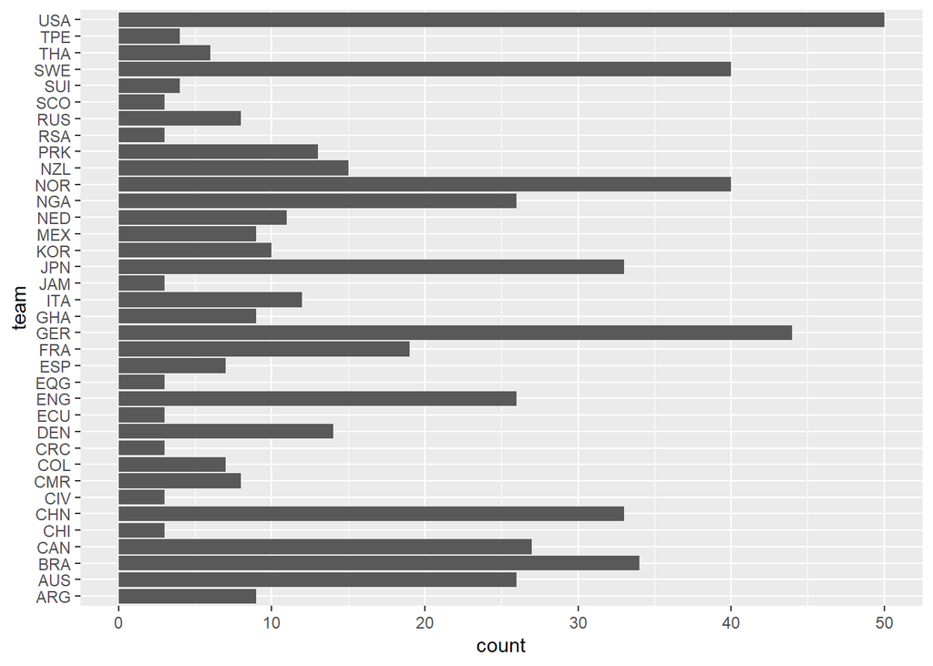

```r
head(codes)
head(wwc_outcomes)

## We might not know what all the team codes stand for:
ggplot(wwc_outcomes, aes(x = team)) +
  geom_bar() +
  coord_flip()
```

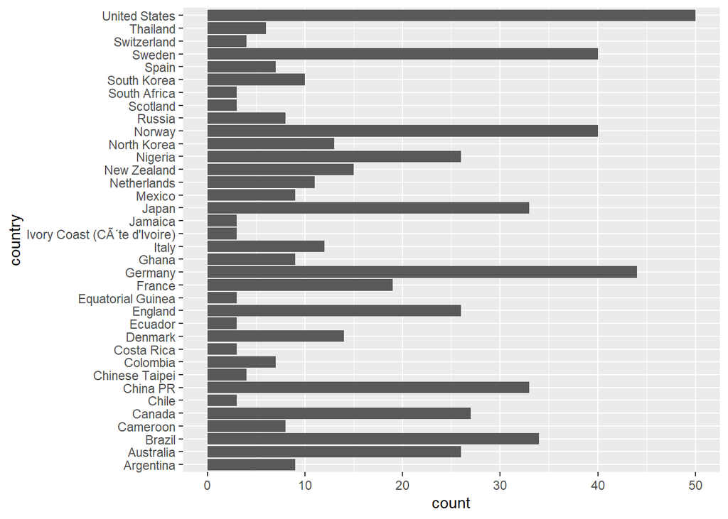

```r
## but we have them stored in the codes dataframe that we read in at the start:
wwc_outcomes_c <- left_join(wwc_outcomes, codes, by = "team")

## Now we can see which teams played the most games:
ggplot(wwc_outcomes_c, aes(x = country)) +
  geom_bar() +
  coord_flip()
```

The function `left_join()` retains the dataframe that we specify first, and adds in values from the dataframe we specify next. There are different `join()` functions and they do differnt things. When I use these functions I check and double check what exactly each function does, as it can get a bit confusing:

```r
all_countries <- right_join(wwc_outcomes, codes, by = "team")
# right_join will keep all the data from codes, and add the data from wwc_outcomes in front of it
```

> What does anti_join() do? Try it with wwc_outcomes and codes.

## 5. Piping %>% and group_by()

If we need to do a lot of data manipulation in a dataframe, we can use piping, with the piping operator `%>%`. Have a look at this **shockingly untidy** example from earlier:

```r
finals <- filter(wwc_outcomes, round == "Final")
finals <- select(finals, year, team, win_status)
finals <- pivot_wider(finals, names_from = win_status, values_from = team)
```

If we use piping, we can reduce the code and have less opportunities for misspellings etc. I have written the code below with pipes, but it does exactly the same as the code above:

```r
wwc_outcomes %>%
  filter(round == "Final") %>%
  select(year, team, win_status) %>%
  pivot_wider(names_from = win_status, values_from = team) ->
  finals

# rather than having to write wwc_outcomes at the start of each bracket, we don't need to write it apart from the first part of the code
# to save what we are doing, we need to end the code with ->, followed by the name of the new dataframe on the next line
```

> Compare the code with and witout pipe closely, so you understand how to structure the pipe.

Have a look at this code:

```r
wwc_outcomes2 <- filter(wwc_outcomes, round == "Group")
wwc_outcomes3 <- select(wwc_outcomes2, team, score, win_status)
wwc_outcomes4 <- sample_n(wwc_outcomes3, 20)
```

> Can you turn the above horrible code into a nice pipe? Hint: the keyboard shortcut for the pipe operator is Ctrl + Shift + M

## 6. mutate() and summarise()

We can use `mutate()` to calculate new variables, based on others we already have:

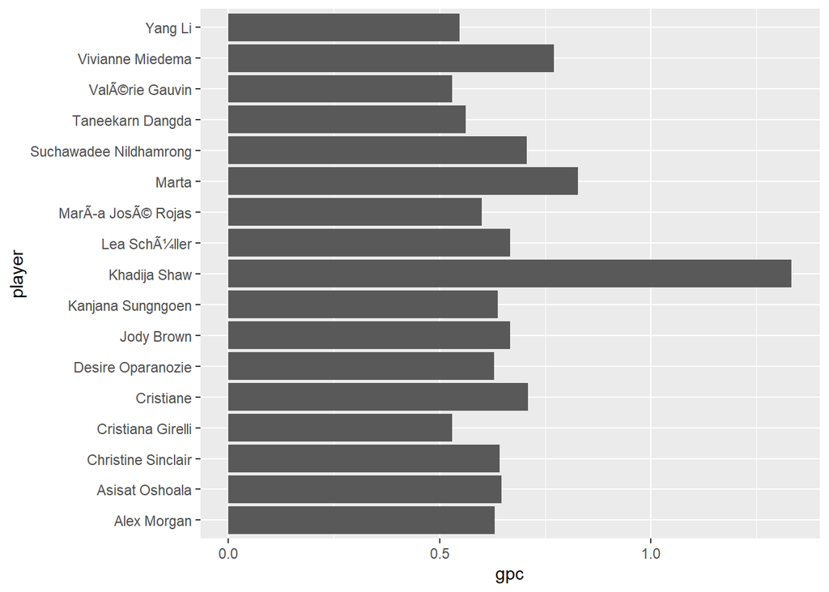

```r
squads <- mutate(squads, gpc = goals / caps)
# the new variable is called gpc. Caps were the number of international games played

squads %>%
  filter(gpc > 0.5) %>%
  ggplot(aes(x = player, y = gpc)) +
  geom_col() +
  coord_flip()
```

`mutate()` can also change variables according to conditions we set:

```r
str(squads)
squads <- mutate_if(squads, is.factor, as.character)
str(squads)
```

We can also group observations with piping, and calculate summary statistics:

```r
squads %>%
  group_by(country) %>%
  summarise(all_goals = sum(goals)) %>%
  filter(all_goals > 200)
```

> Can you calculate the number of games each team played, in wwc_outcomes?

## 7. Reordering factors

R orders factors alphabetically. Often we do not want to display bar plots in this way, but by a frequency or another value. For example, we made the following plot earlier:

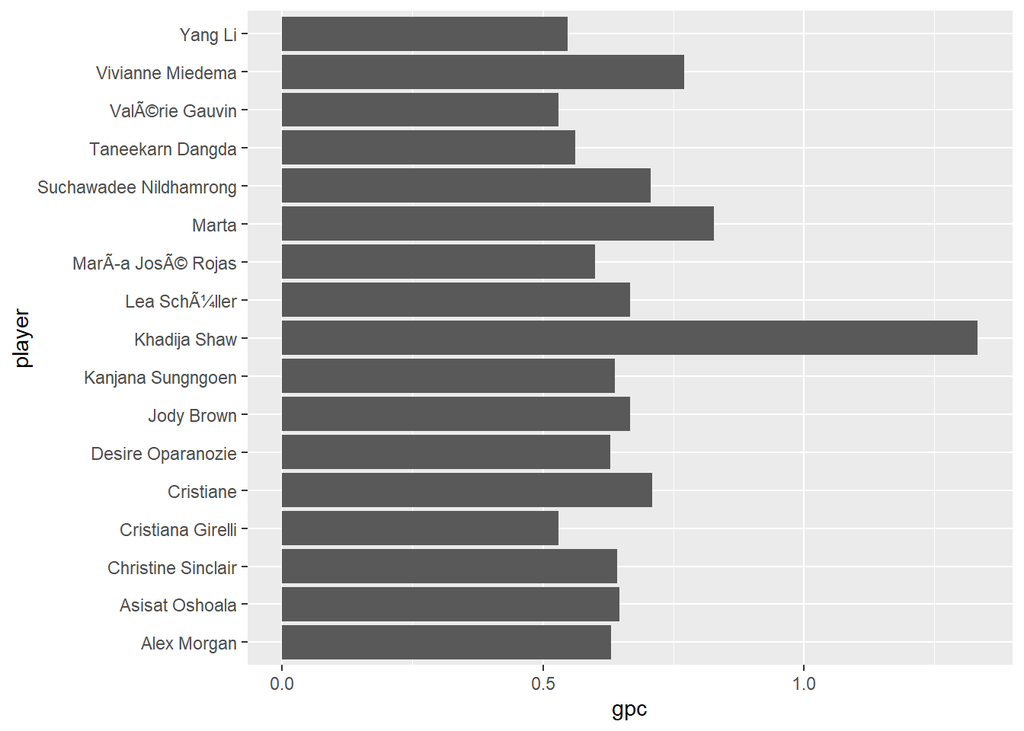

```r
squads %>%
  filter(gpc > 0.5) %>%
  ggplot(aes(x = player, y = gpc)) +
  geom_col() +
  coord_flip()
```

```r
## in reverse alphabetical order, because we used coord_flip()
```

We want to order the plot by gpc really. This is where `fct_reorder()` comes in, which we can use within the `ggplot()` function:

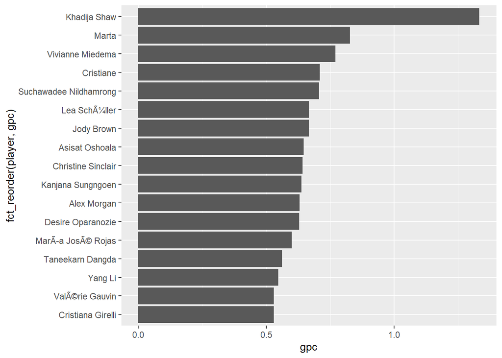

```r
squads %>%
  filter(gpc > 0.5) %>%
  ggplot(aes(x = fct_reorder(player, gpc), y = gpc)) +
  geom_col() +
  coord_flip()
```

> Can you reverse the order, so the highest gpc is at the bottom? Use the Factors with forcats Cheat Sheet.

Sometimes we might want to order by the frequency, particularly for barplots. Another plot we made earlier:

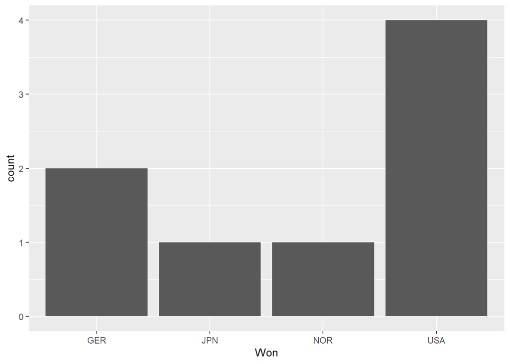

```r
ggplot(finals_wide, aes(x = Won)) +
  geom_bar()
```

We can use the `fct_infreq()` function to reorder:

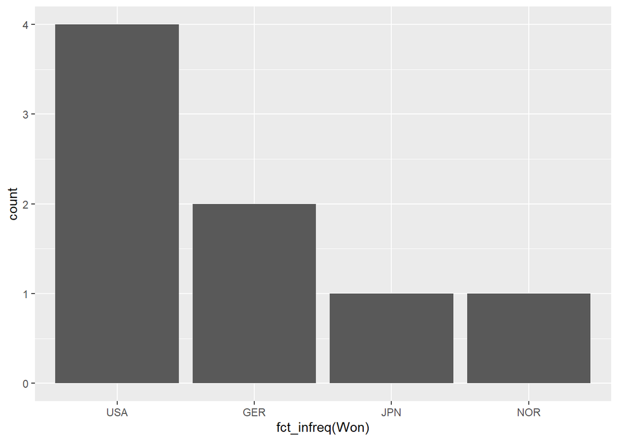

```r
ggplot(finals_wide, aes(x = fct_infreq(Won))) +
  geom_bar()
```

## 8. A bit more on factors

Sometimes we want to change the names of a factor, because they are too long, or are incorrect. We can check and change individual factor levels like this:

```r
levels(wwc_outcomes$win_status)
levels(wwc_outcomes$win_status) <- c("Lost", "Tie", "Winners YAAAY")
levels(wwc_outcomes$win_status)[levels(wwc_outcomes$win_status) == "Lost"] <- "Losers :("
## this just changes one factor level
```

If we want to display factor levels over 2 lines because they are so long, we can change them in this way using `\n`:

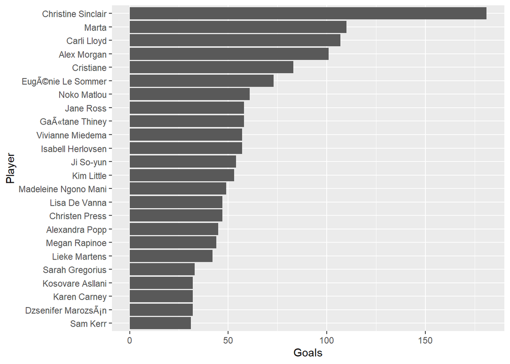

```r
ggplot(data = goals30, aes(x = fct_reorder(player, goals), y = goals)) +
  geom_col() +
  coord_flip() +
  labs(x = "Player", y = "Goals")
```

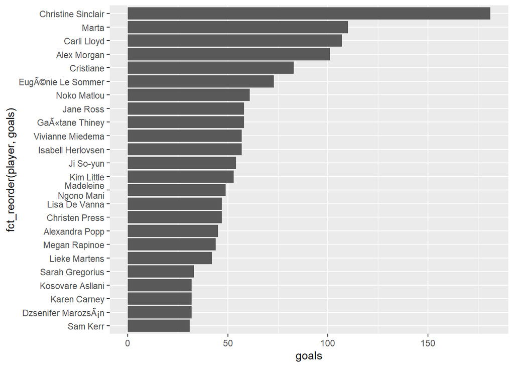

```r
levels(goals30$player)[levels(goals30$player) == "Madeleine Ngono Mani"]<-"Madeleine\nNgono Mani"

ggplot(data = goals30, aes(x = fct_reorder(player, goals), y = goals)) +
  geom_col() +
  coord_flip()
```